# Project Python Foundations: FoodHub Data Analysis

### Context

The number of restaurants in New York is increasing day by day. Lots of students and busy professionals rely on those restaurants due to their hectic lifestyles. Online food delivery service is a great option for them. It provides them with good food from their favorite restaurants. A food aggregator company FoodHub offers access to multiple restaurants through a single smartphone app.

The app allows the restaurants to receive a direct online order from a customer. The app assigns a delivery person from the company to pick up the order after it is confirmed by the restaurant. The delivery person then uses the map to reach the restaurant and waits for the food package. Once the food package is handed over to the delivery person, he/she confirms the pick-up in the app and travels to the customer's location to deliver the food. The delivery person confirms the drop-off in the app after delivering the food package to the customer. The customer can rate the order in the app. The food aggregator earns money by collecting a fixed margin of the delivery order from the restaurants.

### Objective

The food aggregator company has stored the data of the different orders made by the registered customers in their online portal. They want to analyze the data to get a fair idea about the demand of different restaurants which will help them in enhancing their customer experience. Suppose you are hired as a Data Scientist in this company and the Data Science team has shared some of the key questions that need to be answered. Perform the data analysis to find answers to these questions that will help the company to improve the business.

### Data Description

The data contains the different data related to a food order. The detailed data dictionary is given below.

### Data Dictionary

- order_id: Unique ID of the order
- customer_id: ID of the customer who ordered the food
- restaurant_name: Name of the restaurant
- cuisine_type: Cuisine ordered by the customer
- cost_of_the_order: Cost of the order
- day_of_the_week: Indicates whether the order is placed on a weekday or weekend (The weekday is from Monday to Friday and the weekend is Saturday and Sunday)
- rating: Rating given by the customer out of 5
- food_preparation_time: Time (in minutes) taken by the restaurant to prepare the food. This is calculated by taking the difference between the timestamps of the restaurant's order confirmation and the delivery person's pick-up confirmation.
- delivery_time: Time (in minutes) taken by the delivery person to deliver the food package. This is calculated by taking the difference between the timestamps of the delivery person's pick-up confirmation and drop-off information

### Let us start by importing the required libraries

```python
# Installing the libraries with the specified version.
!pip install numpy==1.25.2 pandas==1.5.3 matplotlib==3.7.1 seaborn==0.13.1 -q --user
```

[output not shown]

**Note**:

- After running the above cell, kindly restart the runtime (for Google Colab) or notebook kernel (for Jupyter Notebook), and run all cells sequentially from the next cell.
- On executing the above line of code, you might see a warning regarding package dependencies. This error message can be ignored as the above code ensures that all necessary libraries and their dependencies are maintained to successfully execute the code in **this notebook**.

```python
# import libraries for data manipulation
import numpy as np
import pandas as pd

# import libraries for data visualization
import matplotlib.pyplot as plt
import seaborn as sns
```

### Understanding the structure of the data

```python
# uncomment and run the below code snippets if the dataset is present in the Google Drive
from google.colab import drive
drive.mount('/content/drive')
```

```python
# Write your code here to read the data
data = pd.read_csv('/content/drive/My Drive/AIML/foodhub_order.csv')
```

```python
# Write your code here to view the first 5 rows
data.head()
```

|  | order_id | customer_id | restaurant_name | cuisine_type | cost_of_the_order | day_of_the_week | rating | food_preparation_time | delivery_time |
| --- | --- | --- | --- | --- | --- | --- | --- | --- | --- |
| 0 | 1477147 | 337525 | Hangawi | Korean | 30.75 | Weekend | Not given | 25 | 20 |
| 1 | 1477685 | 358141 | Blue Ribbon Sushi Izakaya | Japanese | 12.08 | Weekend | Not given | 25 | 23 |
| 2 | 1477070 | 66393 | Cafe Habana | Mexican | 12.23 | Weekday | 5 | 23 | 28 |
| 3 | 1477334 | 106968 | Blue Ribbon Fried Chicken | American | 29.20 | Weekend | 3 | 25 | 15 |
| 4 | 1478249 | 76942 | Dirty Bird to Go | American | 11.59 | Weekday | 4 | 25 | 24 |

### **Question 1:** How many rows and columns are present in the data? [0.5 mark]

```python
# Write your code here
data.shape
# we have 1898 rows and 9 columns
```

```
(1898, 9)
```

#### Observations:

The dataset contains 1898 rows, meaning our dataset has a total of 1898 individual food orders and has 9 rows meaning 9 attributes describing each order.

### **Question 2:** What are the datatypes of the different columns in the dataset? (The info() function can be used) [0.5 mark]

```python
# Write your code here
data.info()
```

```
<class 'pandas.core.frame.DataFrame'>
RangeIndex: 1898 entries, 0 to 1897
Data columns (total 9 columns):
 #   Column                 Non-Null Count  Dtype
---  ------                 --------------  -----
 0   order_id               1898 non-null   int64
 1   customer_id            1898 non-null   int64
 2   restaurant_name        1898 non-null   object
 3   cuisine_type           1898 non-null   object
 4   cost_of_the_order      1898 non-null   float64
 5   day_of_the_week        1898 non-null   object
 6   rating                 1898 non-null   object
 7   food_preparation_time  1898 non-null   int64
 8   delivery_time          1898 non-null   int64
dtypes: float64(1), int64(4), object(4)
memory usage: 133.6+ KB
```

#### Observations:

- order_id (int64) => Consist of numeric value representing unique orderIds
- customer_id (int64) => Consist of numeric value representing customers Id
- restaurant_name (object) => This is text value displaying name of the restaurant
- cuisine_type (object) => This is text value displaying name of the cuisine ordered by the customer
- cost_of_the_order (float64) => Numeric values with decimals representing total cost of the order
- day_of_the_week (object) => This is text value 'Weekend' or 'Weekday' where Mon - Fri is mentioned as Weekday and Sat and Sun is mentioned as weekend
- rating (object) => Although ratings are numeric values, missing values are entered as 'not given' has showing as object. This field should be converted to numeric after handling missing values.
- food_preparation_time (int64) => Numeric values representing food preparation time in mins
- delivery_time (int64) => Numeric values representing delivery time in mins (food delivery time - food pickup time)

We have 4 integer columns: order_id, customer_id, food_preperation_time and delivery_time.

1 floar column: cost_of_the_order

4 object / string columns: restaurant_name, cuisine_type, day_of_the_week, and rating

All columns have 1898 Non Null values indicating there is no missing data.

### **Question 3:** Are there any missing values in the data? If yes, treat them using an appropriate method. [1 mark]

```python
# Write your code here

# checking for any missing values in all the columns
data.isnull().sum()
# There are missing values in the dataset

# Hovever the 'rating' column is stored as an object type because it includes the string 'Not given'.
# Since ratings can only be between 1 to 5, 'Not given' should be treated as a missing value (NaN).
# However, around 40% of ratings are missing, which is quite significant.
# Imputing such a large portion of data may introduce bias, especially since ratings are subjective.
# Therefore, we will keep 'Not given' as NaN to accurately represent unrated orders.
# After replacement, the column will be converted to a numeric type.

data['rating'] = data['rating'].replace('Not given', np.nan)
# data['rating'] = data['rating'].replace(['Not given'], np.nan)

# we can confirm that we have replaces the value
data['rating'].unique()

# converting the rating field to float
data['rating'] = data['rating'].astype(float)

# Checking the propertion of missing values
data['rating'].value_counts(normalize=True, dropna=False)
```

| rating | proportion |
| --- | --- |
| NaN | 0.387777 |
| 5.0 | 0.309800 |
| 4.0 | 0.203372 |
| 3.0 | 0.099052 |

**dtype:** float64

#### Observations:

There are no explicit missing values in the dataset.

However, based on business understanding, not all customers provide ratings for their orders — these cases are recorded as 'Not given'. For accurate analysis and better visualization, the 'rating' field was converted to a numeric type (float), and 'Not given' values were replaced with NaN to properly represent missing ratings.

### **Question 4:** Check the statistical summary of the data. What is the minimum, average, and maximum time it takes for food to be prepared once an order is placed? [2 marks]

```python
# Write your code here

# Statistical summary for dataset
data.describe(include= 'all').T
```

|  | count | unique | top | freq | mean | std | min | 25% | 50% | 75% | max |
| --- | --- | --- | --- | --- | --- | --- | --- | --- | --- | --- | --- |
| order_id | 1898.0 | NaN | NaN | NaN | 1477495.5 | 548.049724 | 1476547.0 | 1477021.25 | 1477495.5 | 1477969.75 | 1478444.0 |
| customer_id | 1898.0 | NaN | NaN | NaN | 171168.478398 | 113698.139743 | 1311.0 | 77787.75 | 128600.0 | 270525.0 | 405334.0 |
| restaurant_name | 1898 | 178 | Shake Shack | 219 | NaN | NaN | NaN | NaN | NaN | NaN | NaN |
| cuisine_type | 1898 | 14 | American | 584 | NaN | NaN | NaN | NaN | NaN | NaN | NaN |
| cost_of_the_order | 1898.0 | NaN | NaN | NaN | 16.498851 | 7.483812 | 4.47 | 12.08 | 14.14 | 22.2975 | 35.41 |
| day_of_the_week | 1898 | 2 | Weekend | 1351 | NaN | NaN | NaN | NaN | NaN | NaN | NaN |
| rating | 1162.0 | NaN | NaN | NaN | 4.344234 | 0.741478 | 3.0 | 4.0 | 5.0 | 5.0 | 5.0 |
| food_preparation_time | 1898.0 | NaN | NaN | NaN | 27.37197 | 4.632481 | 20.0 | 23.0 | 27.0 | 31.0 | 35.0 |
| delivery_time | 1898.0 | NaN | NaN | NaN | 24.161749 | 4.972637 | 15.0 | 20.0 | 25.0 | 28.0 | 33.0 |

#### Observations:

The dataset contains 1898 records (orders) and 9 columns.

- It covers information about orders, customers, restaurants, cuisines, ratings, and time taken for food preparation and delivery.
- No explicit missing values are reported, but the 'rating' column includes 'Not given' now converted to Nan entries, representing missing feedback (~39% of total).
- The order_id field contains 1,898 unique, sequential values ranging from 1476547 to 1478444 confirming that each record represents a distinct order with no duplicates.
- The customer_id field contains 1898 values ranging from 1311 to 405334 indicating there are multiple unique customers, some of whom have placed the 1 or more orders during the time period represented in the dataset.
- The dataset includes 178 restaurants, with “Shake Shack” being the most ordered from, accounting for ~11.5% (219/1898) of total orders.
- There are a total of 14 unique cuisines, However American cuisine dominates the dataset, contributing roughly 30% of total orders.
- The average order costs around $16.5, with most orders priced between $12 and $22. The cost distribution is slightly right-skewed, with a few higher-value orders.
- There are 2 categories for the day_of_the_week, Weekday and Weekend, where most orders around 71% of the orders occur on weekends, suggesting higher food delivery activity during weekend.
- There are 4 unique values for Rating 3,4,5 and Not Given / Nan. Ratings are mostly positive (4&5), However around 39% of the orders remains unrated. The overall feedback trends towards higher satisfaction or it can also indicate that most customers only leave a rating when the experience is positive.
- Food preparation times are consistent across orders, averaging around 27 minutes, with standard deviation of around 4.63. The narrow range (20–35 mins) suggests standardized cooking processes among restaurants.
- Deliveries take about 24 minutes on average ranging from 15 - 33 mins, and most are completed within 20–28 minutes (25% - 75%), with a standard deviation of 4.97 a little higher than food preparation time. The small variation indicates reliable delivery performance across restaurants.
- Overall Observation
  - American Cusine and weekend orders are dominating the overall business.
  - Average order costs ~ $16.5, with food preparation and delivery time shows a consistent patterns of around 27 and 24 mins respectively.
  - Overall customer satisfaction is high, although a large portion of orders ~39% remains unrated.

### **Question 5:** How many orders are not rated? [1 mark]

```python
# Write the code here

# Checking the missing values and percentage of it.
data['rating'].value_counts(normalize=False, dropna=False)

# Count how many orders do not have a rating
unrated_orders = data['rating'].isna().sum()



# Total number of orders
total_orders = data.shape[0]

# Calculate percentage of unrated orders
unrated_percentage = (unrated_orders / total_orders) * 100


print(f"Number of unrated orders: {unrated_orders}")
print(f"Percentage of unrated orders: {unrated_percentage:.2f}%") # need to add :.2f to round the float to 2 digits
```

```
Number of unrated orders: 736
Percentage of unrated orders: 38.78%
```

#### Observations:

About 39% of the orders are not rated, indicating that a large portion of customers chose not to provide feedback.

Since this is a significant share of the data, imputing these missing ratings could create bias in the analysis.

Therefore, these missing ratings are retained as valid missing values (NaN) to accurately represent unrated orders.

### Exploratory Data Analysis (EDA)

```python
# Get the unique rating values present in the dataset
# (e.g., 3, 4, 5, and NaN if some ratings are missing)
unique_values = data['rating'].unique()

# Count how many times each rating appears, including NaN values
# dropna=False ensures missing values (NaN) are also counted
frequency = data['rating'].value_counts(dropna=False)

# Count the total number of missing (NaN) ratings in the column
null_values = data['rating'].isna().sum()

# Generate a quick statistical summary of the rating column
# This includes count, number of unique values, most frequent value (top), and its frequency
rating_desc = data['rating'].describe()

# Print all the results for easy reference
print("Unique Values:", unique_values, " \n")
print("Frequency:", frequency, " \n")
print("Null Values:", null_values, " \n")
print("Rating Description:", rating_desc, " \n")
```

```
Unique Values: [nan  5.  3.  4.]

Frequency: rating
NaN    736
5.0    588
4.0    386
3.0    188
Name: count, dtype: int64

Null Values: 736

Rating Description: count    1162.000000
mean        4.344234
std         0.741478
min         3.000000
25%         4.000000
50%         5.000000
75%         5.000000
max         5.000000
Name: rating, dtype: float64
```

### Univariate Analysis

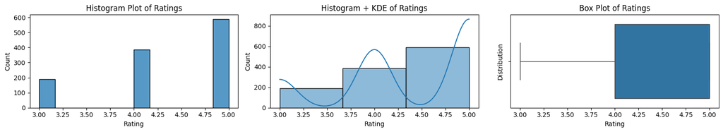

```python
# Count of each rating
data['rating'].value_counts()

# Proportion (percentage)
data['rating'].value_counts(normalize=True) * 100

fig, axes = plt.subplots(1, 3, figsize=(16, 3))

# 1) Histogram plot
sns.histplot(data['rating'], ax=axes[0])
axes[0].set_title('Histogram Plot of Ratings')
axes[0].set_xlabel('Rating')
axes[0].set_ylabel('Count')

# 2) Histogram
sns.histplot(data = data, x = 'rating', bins=3, kde=True, ax=axes[1])
axes[1].set_title('Histogram + KDE of Ratings')
axes[1].set_xlabel('Rating')
axes[1].set_ylabel('Count')

# 3) Box plot
sns.boxplot(x='rating', data=data, ax=axes[2])
axes[2].set_title('Box Plot of Ratings')
axes[2].set_xlabel('Rating')
axes[2].set_ylabel('Distribution')

plt.tight_layout()
plt.show()
```

### **Question 6:** Explore all the variables and provide observations on their distributions. (Generally, histograms, boxplots, countplots, etc. are used for univariate exploration.) [9 marks]

```python
# Write the code here
# In the given data we have 9 attributes so we will go over each attributes below

# --------------------------------------------
# Order_id evalutation
# --------------------------------------------
# We have a total of 1898 orders and the order_id is just a unique id so no additional analysis needed here
print("Order Id Evalutation \n")
print("Total number of orders:", data['order_id'].nunique())
```

```
Order Id Evalutation

Total number of orders: 1898
```

```python
# --------------------------------------------
# Customer_id evalutation
# --------------------------------------------
# Customer_id is unique customer id that is ordering the food. Here we will just check how many customers are ordering multiple orders
customer_order_counts = data['customer_id'].value_counts().reset_index()
customer_order_counts.columns = ['customer_id', 'order_count']

# Customers who have placed more than one order
multiple_orders = customer_order_counts[customer_order_counts['order_count'] > 1]
max_orders = customer_order_counts['order_count'].max()
print("\n Customer Id Evalutation \n")

# Display counts
print(f"Total number of customers: {data['customer_id'].nunique()}")
print(f"Customers with multiple orders: {len(multiple_orders)}")
print(f"The maximum number of orders placed by any customer is: {max_orders}")

# Number of Customers having Number of Orders
order_frequency = customer_order_counts['order_count'].value_counts().sort_index()
print("\n Number of Orders per customer distribution: \n", order_frequency)
```

```
 Customer Id Evalutation

Total number of customers: 1200
Customers with multiple orders: 416
The maximum number of orders placed by any customer is: 13

 Number of Orders per customer distribution:
 order_count
1     784
2     267
3      83
4      33
5      19
6       6
7       4
8       1
9       1
10      1
13      1
Name: count, dtype: int64
```

```
Total number of Restaurants: 178

 Number of Orders per restaurant distribution - top 10:

 restaurant_name
Shake Shack                      219
The Meatball Shop                132
Blue Ribbon Sushi                119
Blue Ribbon Fried Chicken         96
Parm                              68
RedFarm Broadway                  59
RedFarm Hudson                    55
TAO                               49
Han Dynasty                       46
Blue Ribbon Sushi Bar & Grill     44
Name: count, dtype: int64
```

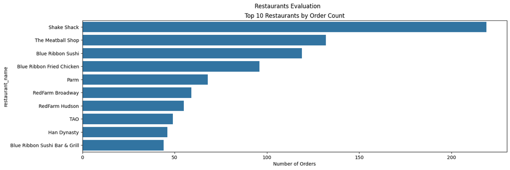

```
 Number of Orders per restaurant distribution - bottom 100:

 restaurant_name
Tortaria                      4
Blue Ribbon Brooklyn          4
Amma                          4
indikitch                     4
Don's Bogam BBQ & Wine Bar    3
                             ..
Rye House                     1
Hiroko's Place                1
Frank Restaurant              1
Sarabeth's West               1
'wichcraft                    1
Name: count, Length: 100, dtype: int64
```

```python
# --------------------------------------------
# Restaurant Name evalutation
# --------------------------------------------

print(f"Total number of Restaurants: {data['restaurant_name'].nunique()}")

top_restaurants = data['restaurant_name'].value_counts().head(10)
print("\n Number of Orders per restaurant distribution - top 10: \n \n", top_restaurants)

plt.figure(figsize=(16,5))
sns.barplot(x=top_restaurants.values, y=top_restaurants.index)
plt.title('Top 10 Restaurants by Order Count')
plt.xlabel('Number of Orders')
plt.suptitle('Restaurants Evaluation')
plt.show()

bottom_restaurants = data['restaurant_name'].value_counts().tail(100)
print("\n Number of Orders per restaurant distribution - bottom 100: \n \n", bottom_restaurants)
```

```
Total number of Cuisine Types: 14

 Number of Orders per cusine distribution:

 cuisine_type
American          584
Japanese          470
Italian           298
Chinese           215
Mexican            77
Indian             73
Middle Eastern     49
Mediterranean      46
Thai               19
French             18
Southern           17
Korean             13
Spanish            12
Vietnamese          7
Name: count, dtype: int64
```

[figure not shown]

```python
# --------------------------------------------
# Cuisine Type evalutation
# --------------------------------------------

print(f"Total number of Cuisine Types: {data['cuisine_type'].nunique()}")

cuisine_frequency = data['cuisine_type'].value_counts()
print("\n Number of Orders per cusine distribution: \n \n", cuisine_frequency)

plt.figure(figsize=(16,5))
sns.countplot(data = data, x='cuisine_type')
plt.title('Cuisine Type by Order Count')
plt.xlabel('Number of Orders')
plt.ylabel('Cuisine')
plt.suptitle('Cuisines Evaluation')
plt.show()
```

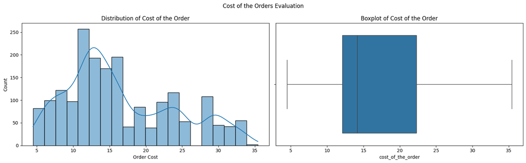

```python
# --------------------------------------------
# Cost of Order evalutation
# --------------------------------------------
fig, axes = plt.subplots(1, 2, figsize=(16,5))

sns.histplot(data = data, x = 'cost_of_the_order', bins=20, kde=True, ax=axes[0])
axes[0].set_title('Distribution of Cost of the Order')
axes[0].set_xlabel('Order Cost')
axes[0].set_ylabel('Count')

sns.boxplot(x=data['cost_of_the_order'], ax=axes[1])
axes[1].set_title('Boxplot of Cost of the Order')

plt.suptitle('Cost of the Orders Evaluation')
plt.tight_layout()
plt.show()
# here we can see the cost_of_the_order is Right-skewed
```

```
 Number of Orders per day of the week distribution:

 day_of_the_week
Weekend    1351
Weekday     547
Name: count, dtype: int64
```

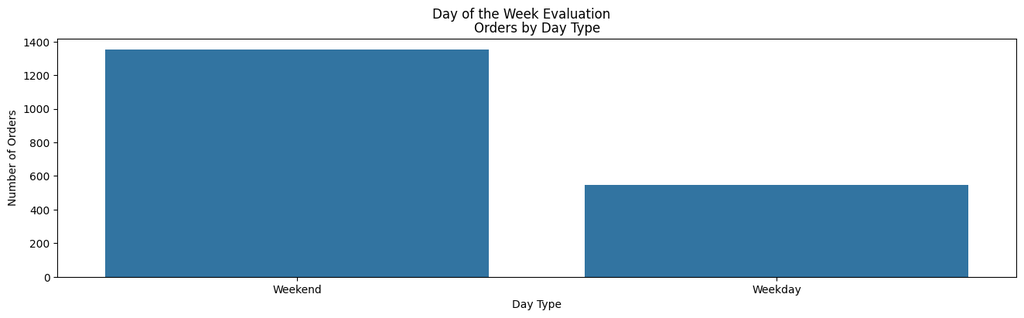

```python
# --------------------------------------------
# Day of the Week evalutation
# --------------------------------------------
day_of_the_week_freq = data['day_of_the_week'].value_counts()
print("\n Number of Orders per day of the week distribution: \n \n", day_of_the_week_freq)

plt.figure(figsize=(16,4))
sns.countplot(x='day_of_the_week', data=data)
plt.title('Orders by Day Type')
plt.xlabel('Day Type')
plt.ylabel('Number of Orders')
plt.suptitle('Day of the Week Evaluation')
plt.show()
```

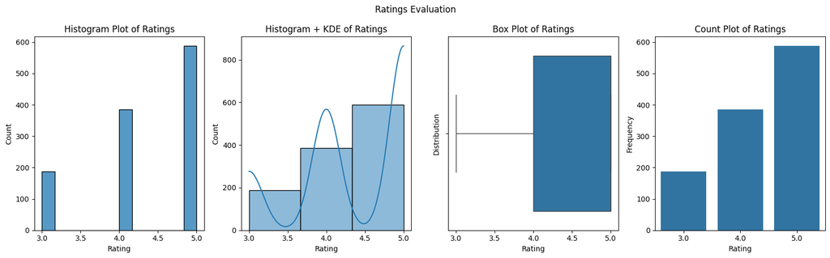

```python
# --------------------------------------------
# Rating evalutation
# --------------------------------------------
fig, axes = plt.subplots(1, 4, figsize=(16, 5))

# 1) Histogram plot
sns.histplot(data['rating'], ax=axes[0])
axes[0].set_title('Histogram Plot of Ratings')
axes[0].set_xlabel('Rating')
axes[0].set_ylabel('Count')

# 2) Histogram
sns.histplot(data = data, x = 'rating', bins=3, kde=True, ax=axes[1])
axes[1].set_title('Histogram + KDE of Ratings')
axes[1].set_xlabel('Rating')
axes[1].set_ylabel('Count')

# 3) Box plot
sns.boxplot(x='rating', data=data, ax=axes[2])
axes[2].set_title('Box Plot of Ratings')
axes[2].set_xlabel('Rating')
axes[2].set_ylabel('Distribution')

# 4) Count plot
sns.countplot(x='rating', data=data, ax=axes[3])
axes[3].set_title('Count Plot of Ratings')
axes[3].set_xlabel('Rating')
axes[3].set_ylabel('Frequency')

plt.suptitle('Ratings Evaluation')
plt.tight_layout()
plt.show()

# Rating is slightly left skewed
```

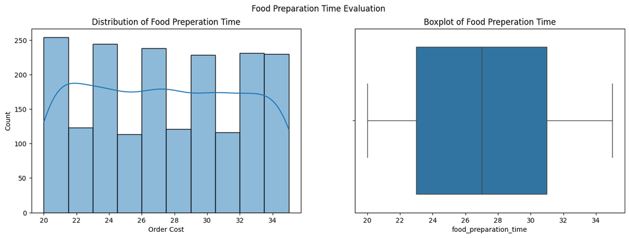

```python
# --------------------------------------------
# Food Preparation time of Order evalutation
# --------------------------------------------
fig, axes = plt.subplots(1, 2, figsize=(16,5))

sns.histplot(data['food_preparation_time'], bins=10, kde=True, ax=axes[0])
axes[0].set_title('Distribution of Food Preperation Time')
axes[0].set_xlabel('Order Cost')
axes[0].set_ylabel('Count')

sns.boxplot(x=data['food_preparation_time'], ax=axes[1])
axes[1].set_title('Boxplot of Food Preperation Time')

plt.suptitle('Food Preparation Time Evaluation')
plt.show()

# here we can see the food_preperation_time looks mostly symmetrical but is slightly Right skewed
```

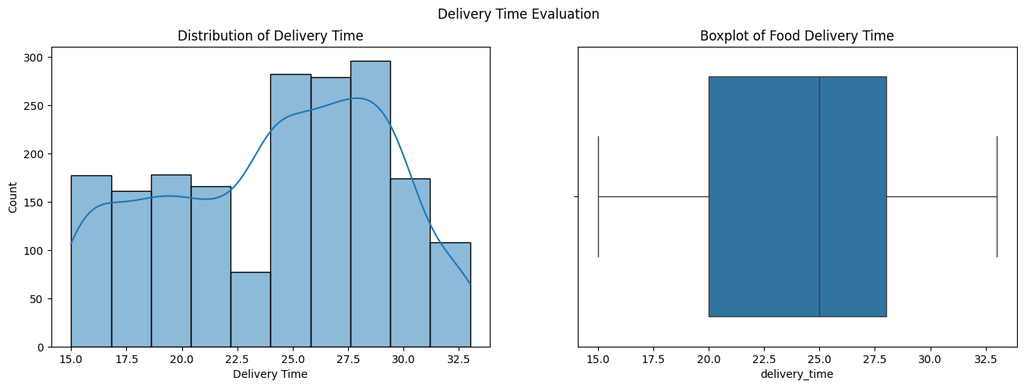

```python
# --------------------------------------------
# Food Delivery time of Order evalutation
# --------------------------------------------
fig, axes = plt.subplots(1, 2, figsize=(16,5))

sns.histplot(data['delivery_time'], bins=10, kde=True, ax=axes[0])
axes[0].set_title('Distribution of Delivery Time')
axes[0].set_xlabel('Delivery Time')
axes[0].set_ylabel('Count')

sns.boxplot(x=data['delivery_time'], ax=axes[1])
axes[1].set_title('Boxplot of Food Delivery Time')
plt.suptitle('Delivery Time Evaluation')
plt.show()
# here we can see the food_preperation_time is sightly left skewed
```

### Observations

- The order_id field contains 1,898 unique, sequential values ranging from 1,476,547 to 1,478,444, confirming that each record represents a distinct order with no duplicates.
- The customer_id field contains 1,898 values ranging from 1,311 to 405,334, indicating there are multiple unique customers.
  - Around 65% of customers placed only one order,
  - One customer placed 13 orders, the highest in the dataset.
- The dataset includes 178 restaurants,
  - “Shake Shack” being the most ordered from, accounting for approximately 11.5% (219 out of 1,898) of total orders.
  - The top three restaurants (Shake Shack, The Meatball Shop, and Blue Ribbon Sushi) together account for around 25% of all orders.
  - The last 50 restaurants have only one order each, and the last 100 restaurants have at most four orders per restaurant.
- There are a total of 14 unique cuisines.
  - However, American cuisine dominates the dataset, contributing roughly 30% of total orders.
  - The top three cuisines (American, Japanese, and Italian) combined account for around 71% of all orders,
  - Bottom six cuisines (Thai, French, Southern, Korean, Spanish, and Vietnamese) together represent only 4.5% of total orders.
- The average order cost is around $16.5, with most orders priced between $12 and $22.
  - The cost distribution is right-skewed, with a few higher-value orders.
- There are two categories for day_of_the_week: Weekday and Weekend.
  - About 71% of orders occur on weekends, suggesting higher food delivery activity during weekends.
- There are four unique values for rating: 3, 4, 5, and Not Given/NaN.
  - Ratings are mostly positive (4 and 5); however, around 39% of orders remain unrated.
  - This trend suggests that customers tend to rate only when they are satisfied, indicating possible positive bias in the feedback.
- Food preparation times are consistent across orders, averaging around 27 minutes, with a standard deviation of 4.63.
  - The narrow range (20–35 minutes) suggests standardized cooking processes among restaurants.
- Delivery times average around 24 minutes, ranging from 15 to 33 minutes.
  - Most deliveries are completed within 20–28 minutes (25th–75th percentile), with a standard deviation of 4.97, slightly higher than food preparation time.
  - The small variation indicates reliable delivery performance across restaurants.

### **Question 7**: Which are the top 5 restaurants in terms of the number of orders received? [1 mark]

```
 Number of Orders per restaurant distribution - top 5:

 restaurant_name
Shake Shack                  219
The Meatball Shop            132
Blue Ribbon Sushi            119
Blue Ribbon Fried Chicken     96
Parm                          68
Name: count, dtype: int64
```

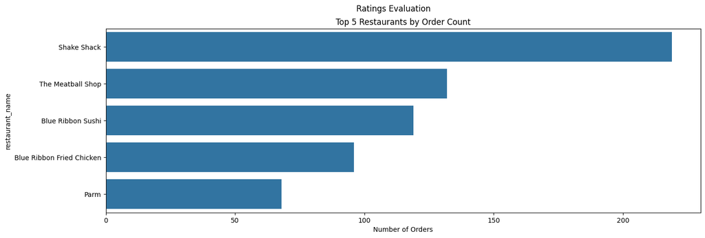

```python
# Write the code here

top_restaurants = data['restaurant_name'].value_counts().head(5)
print("\n Number of Orders per restaurant distribution - top 5: \n \n", top_restaurants)

plt.figure(figsize=(16,5))
sns.barplot(x=top_restaurants.values, y=top_restaurants.index)
plt.title('Top 5 Restaurants by Order Count')
plt.xlabel('Number of Orders')
plt.suptitle('Ratings Evaluation')
plt.show()
```

#### Observations:

The dataset includes 178 restaurants,

- “Shake Shack” is the most ordered from, accounting for approximately 11.5% (219 out of 1,898) of total orders.
- The top three restaurants (Shake Shack, The Meatball Shop, and Blue Ribbon Sushi) together account for around 25% of all orders.
- The top five restaurants combined contribute to about 33% of total orders.

### **Question 8**: Which is the most popular cuisine on weekends? [1 mark]

```python
# Write the code here
weekend_data = data[data['day_of_the_week'] == 'Weekend']

# Find the most popular cuisine on weekends
popular_weekend_cuisine = weekend_data['cuisine_type'].value_counts().idxmax()
popular_weekend_cuisine_count = weekend_data['cuisine_type'].value_counts().max()

print(f"Most popular cuisine on weekends: {popular_weekend_cuisine} ({popular_weekend_cuisine_count} orders)")
```

```
Most popular cuisine on weekends: American (415 orders)
```

#### Observations:

- The most popular cuisine on weekends is American, consistent with its dominance in the overall dataset.
  - Weekend orders account for around 71% of total orders, and American cuisine remains the top choice, with 415 weekend orders — approximately 22% of all orders.
  - This shows that customer preference for American cuisine is consistently strong, even during weekends when order volume is highest.

### **Question 9**: What percentage of the orders cost more than 20 dollars? [2 marks]

```python
# Write the code here
total_orders = data.shape[0]
orders_over_20 = data[data['cost_of_the_order'] > 20].shape[0]

# Calculate percentage
percent_over_20 = (orders_over_20 / total_orders) * 100

print(f"Orders costing more than $20: {orders_over_20} ({percent_over_20:.2f}%)")
```

```
Orders costing more than $20: 555 (29.24%)
```

#### Observations:

- Out of 1,898 total orders, 555 orders cost more than 20 dollars, accounting to arround 29% of all orders.
  - This mean that nearly three out of every 10 orders fall into the higher-priced category, while the majority of the customers prefer meals under 20 dollars.

### **Question 10**: What is the mean order delivery time? [1 mark]

```python
# Write the code here
mean_delivery_time = data['delivery_time'].mean()
print(f"Mean order delivery time: {mean_delivery_time:.2f} minutes")
```

```
Mean order delivery time: 24.16 minutes
```

#### Observations:

- The average (mean) order delivery time is approximately 24.16 minutes.
- This indicates that, on average, customers receive their orders within 24 minutes, reflecting a consistent and efficient delivery process across restaurants.
- Order delivery time is slightly less-skewed with mean of around 24.16 and median of 25

### **Question 11:** The company has decided to give 20% discount vouchers to the top 3 most frequent customers. Find the IDs of these customers and the number of orders they placed. [1 mark]

```python
# Write the code here
customer_order_counts = data['customer_id'].value_counts().head(3)

print("Top 3 most frequent customers:")
print(customer_order_counts)
```

```
Top 3 most frequent customers:
customer_id
52832    13
47440    10
83287     9
Name: count, dtype: int64
```

#### Observations:

The top three most frequent customers are:

- Customer ID 52832 with 13 orders
- Customer ID 47440 with 10 orders
- Customer ID 83287 with 9 orders

These customers qualify for the company’s 20% discount vouchers, as they represent the most loyal and frequent buyers in the dataset.